# Project: Communicate Data Findings - Lyft Bay Wheels

## by Fred Schmidt

1. Introduction
2. Visualizations
3. Conclusion  
   Resources

# 1. Introduction

## Investigation Overview

Bay Wheels is a public bicycle sharing company in the San Francisco Bay Area, California owned by the ridesharing company **Lyft Inc**. Bay Wheels is the first regional and large-scale bicycle sharing system deployed in California and on the West Coast of the United States.

It was established as **Bay Area Bike Share** in August 2013. In June 2017, the system was re-launched as **Ford GoBike** in a partnership with Ford Motor Company. After Motivate's acquisition by Lyft, it was renamed to **Bay Wheels** in June 2019.

The key goal of this presentation is to identify business and grwoth oportunities in the bike sharing industry. The service users and operations of the Lyft Bay Wheels system will be analyzed using univariate, bivariate and multivariate visualizations.

## Dataset Overview

- The cleaned database analyzed in this presentation captures **~5,800,000 bike rides from Juny 26th 2017 to March 31st 2020**.
- The following information is available for a bike ride:
  - Duration in seconds
  - Start time
  - End time
  - Start station ID, start station name
  - Start station latitude, start station longitude
  - End station ID, end station name
  - End station latitude, end station longitude
  - Bike ID
  - User type
  - Bike share for all trip
- Data types:
  - Datetime: Start time, end time
  - Numerical: e.g. Duration in seconds, start station ID, end station ID
  - Categorical: User type, weekday, weekday or not (binary)

## The Fleet

As of January 2018, the Bay Wheels system had **over 2,600 bicycles in 262 stations** across San Francisco, East Bay and San Jose.

The Bay Wheels fleet consists of two kinds of bicycles:

1. **Classic**
2. **Hybrid** (electric-assist)

## Pricing

The bicycles are available 24 hours a day, seven days a week for periods ranging from a single ride (up to 30 minutes) to a day pass. In January 2018, the Bay Wheels system had about 10,000 annual subscribers. There are two types of Lyft service users:

**1. Subscribers**

- Annual membership: \$149/year
- Benefits:
  - 45 mins of ride time vs. 30 mins for Customers
  - Unlimited rides up to 45 mins in duration
  - E-bike upgrade for $0.15/min
- Day pass available for \$10/day

**2. Customers**

- No fixed costs
- First 30 mins: \$2
- Additional 15 mins: \$2
- Day pass available for \$10/day

# 2. Visualizations

## 2.1 Duration of bike rides

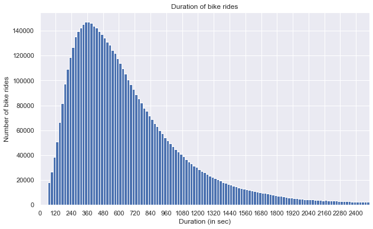

```python
treshold = 2500
x_ticks = np.arange(0, treshold, 120)
bin_size = np.arange(0, treshold+20, 20)

plt.figure(figsize=(10,6))
plt.hist(df_clean['duration_sec'][df_clean['duration_sec'] <= treshold], bins=bin_size)
plt.title('Duration of bike rides')
plt.xlabel('Duration (in sec)'), plt.ylabel('Number of bike rides')
plt.xticks(x_ticks, x_ticks), plt.xlim(0, treshold);
```

**Findings:**

## 2.2 Bike usage over the week

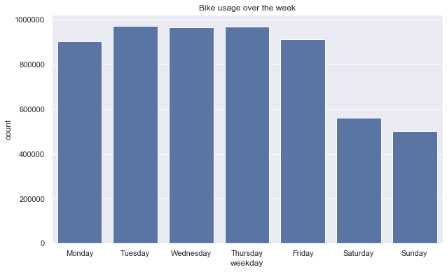

```python
plt.figure(figsize=(10,6))
sns.countplot(data=df_clean, x='weekday', color=base_color)
plt.title('Bike usage over the week')
plt.xticks([0, 1, 2, 3, 4, 5, 6], ['Monday', 'Tuesday', 'Wednesday', 'Thursday', 'Friday', 'Saturday', 'Sunday']);
```

**Findings:**

## 2.3 Bike usage over the day

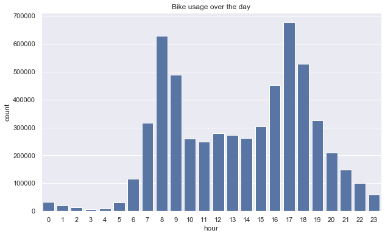

```python
plt.figure(figsize=(10,6))
sns.countplot(data=df_clean, x='hour', color=base_color)
plt.title('Bike usage over the day');
```

**Findings:**

- There are clear peaks at rush hour, i.e. **between 7am and 9am** and **between 4pm and 6pm**, probably due to commuters.
- If this is true, we should see differences in the bike usage over the day when we consider weekdays and weekend separately. This is where **bivariate analysis** will be powerful later on.

## 2.4 Share of total bike rides per user type

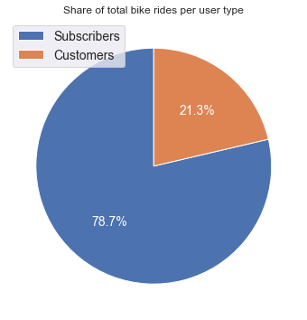

```python
plt.figure(figsize=(10,6))
plt.pie(df_clean['user_type'].value_counts(),
        autopct='%1.1f%%', startangle=90, textprops=dict(color="w", size=14))
plt.legend(['Subscribers', 'Customers'], loc='upper left', fontsize=14, frameon=True)
plt.title('Share of total bike rides per user type');
```

**Findings:**

- From the 5,800,000 bike rides, about **20%** can be assigned to **Customers** and about **80%** to **Subscribers**.
- Note: This does not indicate that most Bay Wheels users are Subscribers. It simply means that Subscribers account for most trips. Whether or not Subscribers use the service more often cannot be analyzed, because of a missing user ID.

## 2.5 Development over time

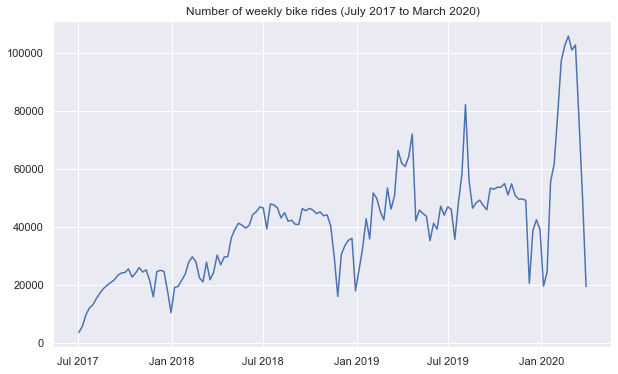

```python
df_time = df_clean.groupby(['year', 'week'])['bike_id'].count().reset_index().rename(
    columns={'bike_id':'count'})

# Convert year and week to date
dates = df_time['year'] * 100 + df_time['week']
df_time['date'] = pd.to_datetime(dates.astype(str) + '0', format='%Y%W%w')

# Results may be distorted if the last week has less than 7 days and counts as a full week
# Drop incomplete weeks
df_time = df_time[df_time['date'] < '2020-04-01']

x_ticks_old = [np.datetime64('2017-07'), np.datetime64('2018-01'), np.datetime64('2018-07'),
               np.datetime64('2019-01'), np.datetime64('2019-07'), np.datetime64('2020-01')]
x_ticks_new = ['Jul 2017', 'Jan 2018', 'Jul 2018', 'Jan 2019', 'Jul 2019', 'Jan 2020']

plt.figure(figsize=(10,6))
plt.plot(df_time['date'], df_time['count'])
plt.title('Number of weekly bike rides (July 2017 to March 2020)')
plt.xticks(x_ticks_old, x_ticks_new);
```

**Finding 1:**

- There is an overall positive trend.

**Finding 2:**

- There are two obvious drops over the year:
  - one in the last year of the week (**Christmas**),
  - and second one about four weeks earlier (**Thanksgiving**).
- The number of bike rentals during these weeks are expected to be lower because of less commuters.
- See below: Indeed, we see that there are almost no peaks in the morning and in the evening in the Christmas week.

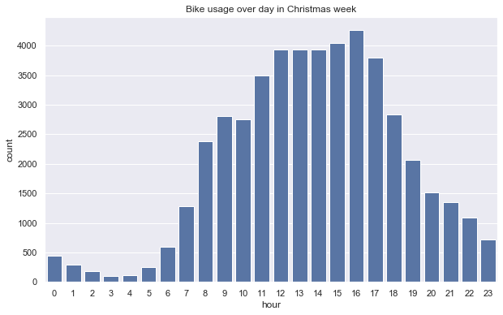

```python
plt.figure(figsize=(10,6))
sns.countplot(data=df_clean[(df_clean['week'] == 52)], x='hour', color=base_color)
plt.title('Bike usage over day in Christmas week');
```

**Finding 3:**

- The plot reveals seasonality over the year: There are more bike rides in the summer.

**Finding 4:**

- There is a huge peak and drop in 2020. They also appear in the raw data. This may be due to special marketing activities.

## 2.6 Distance traveled

The distance of every bike ride can be derived from the start and end coordinates. This is more a fun plot. We expect the distance of a bike ride to be highly correlated with its duration. Most importantly, duration should be the variable of interest since Lyft earns money with trips that are longer in time, not necessarily with trips that are longer in distance.

Note:

- We assume that users drive directly from A to B.
- We do not consider bike rides with the same start and end station (distance would be 0).

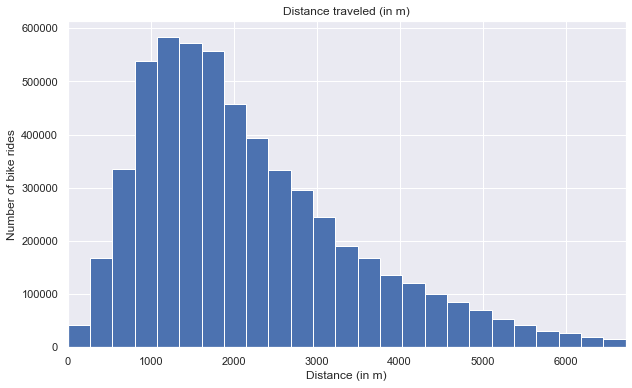

```python
# Do not consider outliers and rides with the same start and end station
plt.figure(figsize=(10,6))
plt.hist(df_clean['meter_distance'][
    (df_clean['meter_distance'] > 0) &
    (df_clean['meter_distance'] <= df_clean['meter_distance'].quantile(0.99))], bins=25)
plt.xlim(0,df_clean['meter_distance'].quantile(0.99))
plt.title('Distance traveled (in m)')
plt.xlabel('Distance (in m)'), plt.ylabel('Number of bike rides');
```

**Findings:**

- The distribution of the distance traveled is unimodal and skewed to the right.
- As expected, it looks similar to the distribution of the duration.
- The center of the distribution is between approximately 1.2km and 1.6km.
- Most bike rides (with different start and end station) are between **0.5km and 3.0km**.

## 2.7 Number of bike rides per weekday for Customers and Subscribers

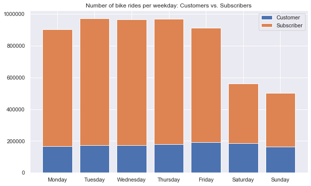

```python
days_order = ['Monday', 'Tuesday', 'Wednesday', 'Thursday', 'Friday', 'Saturday', 'Sunday']
users_order = ['Customer', 'Subscriber']

plt.figure(figsize=(10, 6))
baselines = np.zeros(len(days_order))
# For each second-variable category:
for i in range(len(users_order)):
    # Isolate the counts of Customer and Subscriber
    users = users_order[i]
    # For Customer and Subscriber, count the number of rides per weekday
    inner_counts = df_clean[df_clean['user_type'] == users]['weekday'].value_counts()
    # Plot the counts on top of the accumulated baseline
    plt.bar(x=np.arange(len(days_order)), height=inner_counts[days_order], bottom=baselines)
    # Adjust the baseline for the second group
    baselines += inner_counts[days_order]
plt.xticks(np.arange(len(days_order)), days_order)
plt.legend(users_order)
plt.title('Number of bike rides per weekday: Customers vs. Subscribers');
```

**Findings:**

- The number of bike rides made by **Customers** is **very stable** over the week.
- For **Subscribers**, there is a **difference** between during the week and weekend.
- At a weekend day, Subscribers only make about 50% of the bike rides they make from Monday to Friday.

## 2.8 Bike usage over the day: Weekend vs. no weekend

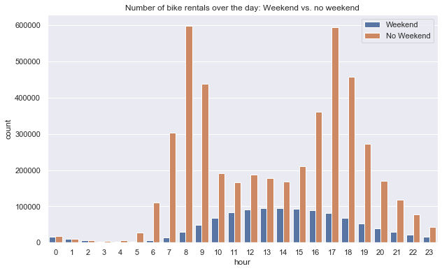

```python
plt.figure(figsize=(10,6))
sns.countplot(data=df_clean, x='hour', hue='dummy_weekday')
plt.legend(title=False)
plt.title('Number of bike rentals over the day: Weekend vs. no weekend');
```

**Findings:**

- The **peaks** in the morning and in the evening only appear **during the week**.
- The distribution of bike rides over the day looks fairly different at the weekend.
- At the **weekend**, the number of bike rides is **distributed smoothly** and achieves a peak between 11am and 4pm.
- In **multivariate exploration**, we will add the user types to see if this holds for both groups.

## 2.9 Duration for Customers and Subscribers

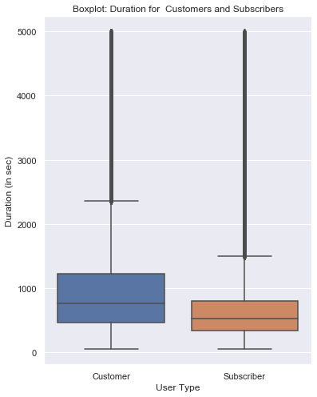

```python
# Do not consider outliers for visual purposes
plt.figure(figsize=(6,8))
sns.boxplot(data=df_clean[df_clean['duration_sec'] < df_clean['duration_sec'].quantile(0.99)],
            x='user_type', y='duration_sec')
plt.xlabel('User Type'), plt.ylabel('Duration (in sec)')
plt.title('Boxplot: Duration for Customers and Subscribers');
```

**Findings:**

- Note: For visual purposes, we dropped the last percentile to get rid of outliers.
- Customers spend more time with a bike than Subscribers.
- On average, **Customers** use a bike for **974 seconds** or about 15 minutes, compared to **Subscribers** with only **639 seconds** or 10 minutes.
- The median duration of a bike rental is 762 seconds while Subscribers have a median rental time of only 530 seconds.
- The day pass option may be more popular among Customers (e.g. tourists) and affect the duration.

## 2.10 Monthly bike rentals for 2018 and 2019

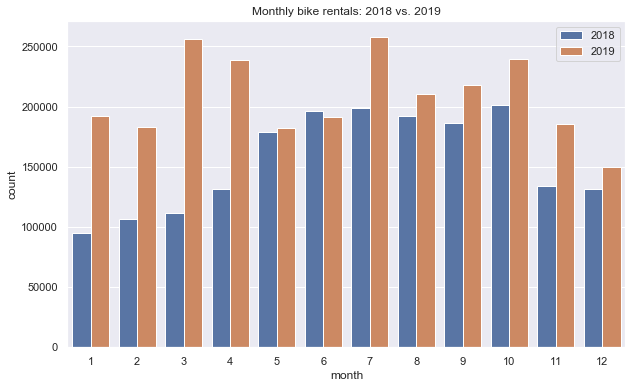

```python
plt.figure(figsize=(10,6))
sns.countplot(data=df_clean[(df_clean['year'] == 2018) | (df_clean['year'] == 2019)],
              x='month', hue='year')
plt.title('Monthly bike rentals: 2018 vs. 2019')
plt.legend(title=False);
```

**Findings:**

## 2.11 Hourly service usage per day for both user types

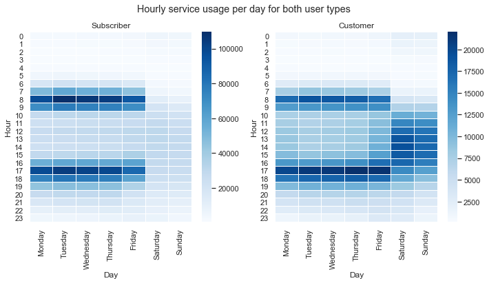

```python
# Create figure
plt.figure(figsize=(10,6))
plt.suptitle('Hourly service usage per day for both user types')
# Put each heatmap into a subplot
for index, value in enumerate(['Subscriber', 'Customer']):
    plt.subplot(1,2,index+1)
    heatmap = df_clean[df_clean['user_type'] == value].groupby(
        ['user_type', 'hour', 'weekday'])['bike_id'].count().unstack().droplevel(level=0)
    sns.heatmap(heatmap, cmap='Blues', linewidths=0.01)
    plt.title('{}'.format(value)), plt.xlabel('Day'), plt.ylabel('Hour')
    plt.yticks(rotation=0)
    plt.tight_layout(rect=[0, 0.03, 1, 0.95]) # Adjust subplots to avoid overlap
```

**Findings:**

- Note: The color maps of both subplots have very different scales.
- **Subscribers** mostly use the service **during the week** for commuting in the morning and the evening. The bikes are used less at the weekend and during the day.
- **Customers** use the service **during the week** in the morning and the evening as well. The bikes are very popular for Customers **at the weekend**, too.

## 2.12 Average ride duration per day for both user types

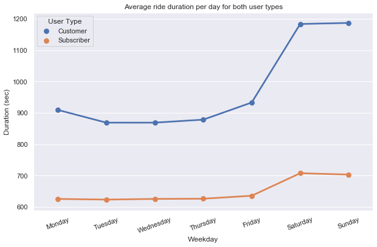

```python
# Do not consider outliers for visual purposes
plt.figure(figsize=(10,6))
sns.pointplot(data=df_clean[df_clean['duration_sec'] <= df_clean['duration_sec'].quantile(0.99)],
            hue='user_type', y='duration_sec', x='weekday');
plt.legend(title='User Type')
plt.title('Average ride duration per day for both user types')
plt.xlabel('Weekday'), plt.ylabel('Duration (sec)'), plt.xticks(rotation=20);
```

**Findings:**

- Both user types make **longer trips at the weekend**. The difference is larger for Customers.
- This may be the affected by **day passes** which are expected to be popular at the weekend.

# 3. Conclusion

## 3.1 Summary

**Duration:**

- Most people use the bikes between 120 seconds and 1200 seconds.

**Over the day:**

- There are clear peaks at rush hour, i.e. between 7am and 9am and between 4pm and 6pm.

**Over the week:**

- The Bay Wheels service is all in all less popular at the weekend.

**Over the year:**

**User types:**

- **Subscribers:**
  - Account for 80% of all bike rides
  - Mostly use the service during the week for commuting
  - 50% less bike rides at a weekend day compared to a day from Monday to Friday.
- **Customers:**
  - Account for 20% of all bike rides
  - Use the service for commuting but also at the weekend
  - Spend more time with a bike than Subscribers

## 3.2 Business Decisions

- Lyft should seek to **achieve a high utilization** of the bikes in their fleet. There may be potential in winter months although Lyft was able to balance the utilization well in 2019).
- **Subscribers** want to get from A to B as quick as possible. They may be interested in faster options: The use of **e-bikes** may be pushed here. This will generate additional revenue.
- At the weekend, there may be potential for selling day passes to **Subscribers**, maybe with a special Subscriber discount.
- Weekend passes in combination with e-bikes, both for **Customers** and **Subscribers**, would increase the radius a service user can reach by bike and create new opportunities.
- **Customers** should be converted **Subscribers** in order to generate recurring revenues. This would increase customer retention and could be effective especially for the customers that use the service for commuting.
- Lyft can reach existing users conveniently and at a low cost via the app.
- Beyond that, Lyft should obviously seek to **increase the customer base**, e.g. with special promotions.
- The bike market, especially the e-bike market, is rising in Europe. There is lots of potential in the US as well.

# Resouces

- Data source: https://www.lyft.com/bikes/bay-wheels/system-data
- Pricing: https://www.lyft.com/bikes/bay-wheels/pricing
- Additional information: https://en.wikipedia.org/wiki/Bay_Wheels